# Bike Sharing Assignment

### 05- 01- 2022

**Business Goal:** We are required to model the demand for shared bikes with the available independent variables. It will be used by the management to understand how exactly the demands vary with different features. They can accordingly manipulate the business strategy to meet the demand levels and meet the customer's expectations. Further, the model will be a good way for management to understand the demand dynamics of a new market.

**Label/Target Column** - cnt

## Setting up the Libraries

```python
# Filtering out the warnings
import warnings
warnings.filterwarnings("ignore")
```

```python
## Importing the required libraries
import numpy as np
import pandas as pd
import matplotlib.pyplot as plt
%matplotlib inline
import seaborn as sns
from sklearn.model_selection import train_test_split
from sklearn.preprocessing import StandardScaler,MinMaxScaler
from sklearn.feature_selection import RFE
from sklearn.linear_model import LinearRegression
from sklearn.metrics import mean_squared_error
from sklearn.metrics import r2_score
import statsmodels.api as sm
from statsmodels.stats.outliers_influence import variance_inflation_factor
```

```python
#Setting Display Options
pd.set_option('display.max_columns', None)
pd.set_option('display.max_rows', None)
```

## Reading & Inspecting the Data

```python
#Reading data.csv dataset using 'read_csv'
bikes_df = pd.read_csv("day.csv")
```

```python
#Checking Data in DataFrame
bikes_df.head()
```

|  | instant | dteday | season | yr | mnth | holiday | weekday | workingday | weathersit | temp | atemp | hum | windspeed | casual | registered | cnt |
| --- | --- | --- | --- | --- | --- | --- | --- | --- | --- | --- | --- | --- | --- | --- | --- | --- |
| 0 | 1 | 01-01-2018 | 1 | 0 | 1 | 0 | 1 | 1 | 2 | 14.110847 | 18.18125 | 80.5833 | 10.749882 | 331 | 654 | 985 |
| 1 | 2 | 02-01-2018 | 1 | 0 | 1 | 0 | 2 | 1 | 2 | 14.902598 | 17.68695 | 69.6087 | 16.652113 | 131 | 670 | 801 |
| 2 | 3 | 03-01-2018 | 1 | 0 | 1 | 0 | 3 | 1 | 1 | 8.050924 | 9.47025 | 43.7273 | 16.636703 | 120 | 1229 | 1349 |
| 3 | 4 | 04-01-2018 | 1 | 0 | 1 | 0 | 4 | 1 | 1 | 8.200000 | 10.60610 | 59.0435 | 10.739832 | 108 | 1454 | 1562 |
| 4 | 5 | 05-01-2018 | 1 | 0 | 1 | 0 | 5 | 1 | 1 | 9.305237 | 11.46350 | 43.6957 | 12.522300 | 82 | 1518 | 1600 |

#### Inspecting the Data

```python
#Checking Total No. of Rows-Columns and Total Null Values in DatFrame
print('########## Dataset Infomation ##########')
print ("Rows                 : " ,bikes_df.shape[0])
print ("Columns              : " ,bikes_df.shape[1])
print ("Total Missing values : ",bikes_df.isnull().sum().values.sum())
```

```
########## Dataset Infomation ##########
Rows                 :  730
Columns              :  16
Total Missing values :  0
```

```python
#Verifying column-wise info of the dataframe
bikes_df.info()
```

```
<class 'pandas.core.frame.DataFrame'>
RangeIndex: 730 entries, 0 to 729
Data columns (total 16 columns):
 #   Column      Non-Null Count  Dtype
---  ------      --------------  -----
 0   instant     730 non-null    int64
 1   dteday      730 non-null    object
 2   season      730 non-null    int64
 3   yr          730 non-null    int64
 4   mnth        730 non-null    int64
 5   holiday     730 non-null    int64
 6   weekday     730 non-null    int64
 7   workingday  730 non-null    int64
 8   weathersit  730 non-null    int64
 9   temp        730 non-null    float64
 10  atemp       730 non-null    float64
 11  hum         730 non-null    float64
 12  windspeed   730 non-null    float64
 13  casual      730 non-null    int64
 14  registered  730 non-null    int64
 15  cnt         730 non-null    int64
dtypes: float64(4), int64(11), object(1)
memory usage: 91.4+ KB
```

```python
#Checking the summary for the numeric columns
bikes_df.describe()
```

|  | instant | season | yr | mnth | holiday | weekday | workingday | weathersit | temp | atemp | hum | windspeed | casual | registered | cnt |
| --- | --- | --- | --- | --- | --- | --- | --- | --- | --- | --- | --- | --- | --- | --- | --- |
| count | 730.000000 | 730.000000 | 730.000000 | 730.000000 | 730.000000 | 730.000000 | 730.000000 | 730.000000 | 730.000000 | 730.000000 | 730.000000 | 730.000000 | 730.000000 | 730.000000 | 730.000000 |
| mean | 365.500000 | 2.498630 | 0.500000 | 6.526027 | 0.028767 | 2.995890 | 0.690411 | 1.394521 | 20.319259 | 23.726322 | 62.765175 | 12.763620 | 849.249315 | 3658.757534 | 4508.006849 |
| std | 210.877136 | 1.110184 | 0.500343 | 3.450215 | 0.167266 | 2.000339 | 0.462641 | 0.544807 | 7.506729 | 8.150308 | 14.237589 | 5.195841 | 686.479875 | 1559.758728 | 1936.011647 |
| min | 1.000000 | 1.000000 | 0.000000 | 1.000000 | 0.000000 | 0.000000 | 0.000000 | 1.000000 | 2.424346 | 3.953480 | 0.000000 | 1.500244 | 2.000000 | 20.000000 | 22.000000 |
| 25% | 183.250000 | 2.000000 | 0.000000 | 4.000000 | 0.000000 | 1.000000 | 0.000000 | 1.000000 | 13.811885 | 16.889713 | 52.000000 | 9.041650 | 316.250000 | 2502.250000 | 3169.750000 |
| 50% | 365.500000 | 3.000000 | 0.500000 | 7.000000 | 0.000000 | 3.000000 | 1.000000 | 1.000000 | 20.465826 | 24.368225 | 62.625000 | 12.125325 | 717.000000 | 3664.500000 | 4548.500000 |
| 75% | 547.750000 | 3.000000 | 1.000000 | 10.000000 | 0.000000 | 5.000000 | 1.000000 | 2.000000 | 26.880615 | 30.445775 | 72.989575 | 15.625589 | 1096.500000 | 4783.250000 | 5966.000000 |
| max | 730.000000 | 4.000000 | 1.000000 | 12.000000 | 1.000000 | 6.000000 | 1.000000 | 3.000000 | 35.328347 | 42.044800 | 97.250000 | 34.000021 | 3410.000000 | 6946.000000 | 8714.000000 |

## DATA CLEANING

#### Dropping the irrelevant columns

```python
#Dropping columns that are not relevant for analysis
bikes_df.drop(['instant','dteday'],axis=1,inplace=True)
```

- `instant` is only row counter that is not useful for the data anaylsis .
- `dteday` becomes irrelevant column as date can be derived from `weekday`,`mnth`and `year` columns.

```python
#Also droppping  'casual' and 'registered' columns also
bikes_df.drop(['casual','registered'],axis=1,inplace=True)
```

- `casual` and `registered` becomes irrelevant column as the target column `cnt` indicates the total number of bike rentals which includes both casual and registered

```python
#Re-inspecting the shape of Dataset after dropping the columns
print('Size of the dataset after dropping the columns: ',bikes_df.shape)
```

```
Size of the dataset after dropping the columns:  (730, 12)
```

#### Handling the Missing value

```python
print("Total No. of Null values are:",bikes_df.isnull().sum().sum())
```

```
Total No. of Null values are: 0
```

**Inferences**

- There are no null values present in any of the column.

## EDA

#### CONVERSION AND MAPPING

```python
#Mapping season column to their values using season_map function

def season_map(s):
    return s.map({1:"spring",2:"summer",3:"fall",4:"winter"})

bikes_df[['season']]= bikes_df[['season']].apply(season_map)
```

```python
#Mapping weathersit column to their values using weathersit_map function

def weathersit_map(ws):
    return ws.map({1:"Clear_Partly cloudy",2:"Mist_cloudy",3:"Light rain_Thunderstorm",4:'Heavy Rain_Ice Pallets'})

bikes_df[['weathersit']] = bikes_df[['weathersit']].apply(weathersit_map)
```

```python
#Mapping month column to their values using month_map function

def month_map(m):
    return m.map({1:'Jan', 2:'Feb', 3:'Mar', 4:'Apr', 5:'May', 6:'Jun', 7:'Jul', 8:'Aug', 9:'Sep', 10:'Oct', 11:'Nov', 12:'Dec'})

bikes_df[['mnth']] = bikes_df[['mnth']].apply(month_map)
```

```python
#Mapping weekday column to their values using weekday_map function

def weekday_map(w):
    return w.map({0:"Sunday",1:"Monday",2:"Tuesday",3:"Wednesday",4:"Thursday",5:"Friday",6:"Saturday"})

bikes_df[['weekday']] = bikes_df[['weekday']].apply(weekday_map)
```

```python
#Checking Data in DataFrame after Mapping
bikes_df.head()
```

|  | season | yr | mnth | holiday | weekday | workingday | weathersit | temp | atemp | hum | windspeed | cnt |
| --- | --- | --- | --- | --- | --- | --- | --- | --- | --- | --- | --- | --- |
| 0 | spring | 0 | Jan | 0 | Monday | 1 | Mist_cloudy | 14.110847 | 18.18125 | 80.5833 | 10.749882 | 985 |
| 1 | spring | 0 | Jan | 0 | Tuesday | 1 | Mist_cloudy | 14.902598 | 17.68695 | 69.6087 | 16.652113 | 801 |
| 2 | spring | 0 | Jan | 0 | Wednesday | 1 | Clear_Partly cloudy | 8.050924 | 9.47025 | 43.7273 | 16.636703 | 1349 |
| 3 | spring | 0 | Jan | 0 | Thursday | 1 | Clear_Partly cloudy | 8.200000 | 10.60610 | 59.0435 | 10.739832 | 1562 |
| 4 | spring | 0 | Jan | 0 | Friday | 1 | Clear_Partly cloudy | 9.305237 | 11.46350 | 43.6957 | 12.522300 | 1600 |

### DATA VISUALIZATION

#### CATEGORICAL VARIABLES

```python
#Creating Categorical_plot function for plotting cnt(Dependent Variable) VS other columns(Independent Variable)
sns.set_style("darkgrid")
def Categorical_plot(col_name):
    plt.figure(figsize=(15, 10))
    plt.subplot(2,1,1)
    sns.boxplot(x = col_name, y = 'cnt', data = bikes_df)
    plt.subplot(2,1,2)
    sns.barplot(x= col_name, y='cnt', data=bikes_df)
    plt.show()
```

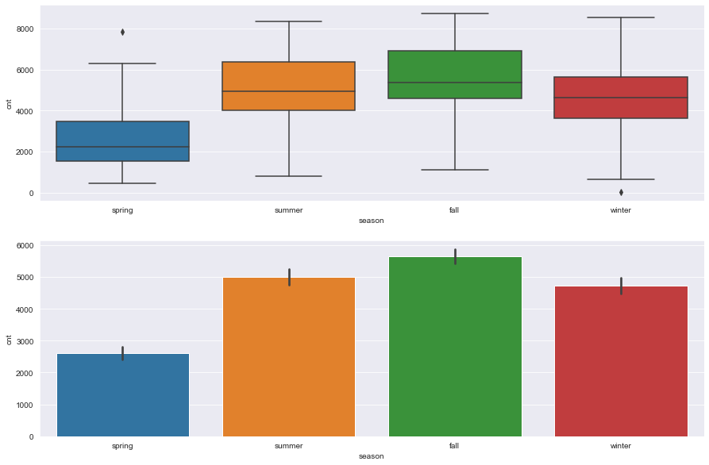

```python
#Plotting Season vs Cnt
Categorical_plot('season')
```

**Inferences**

- `Season` column has low/negligible ouliers count.
- Count of total rental bikes increases in `fall` and `summer` season

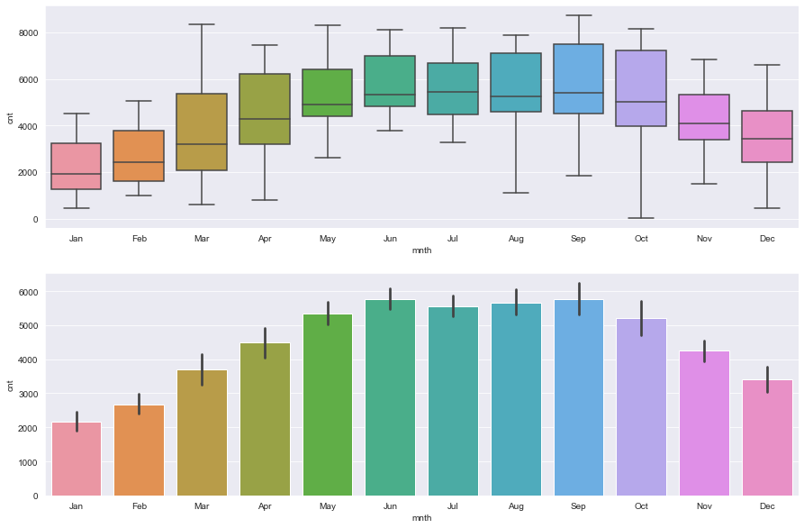

```python
#Plotting month vs Cnt
Categorical_plot('mnth')
```

**Inferences**

- Count of total rental bikes is low in months of `Nov` to `Apr`
- Count of total rental bikes is observed maximum during `May` to `Oct` months

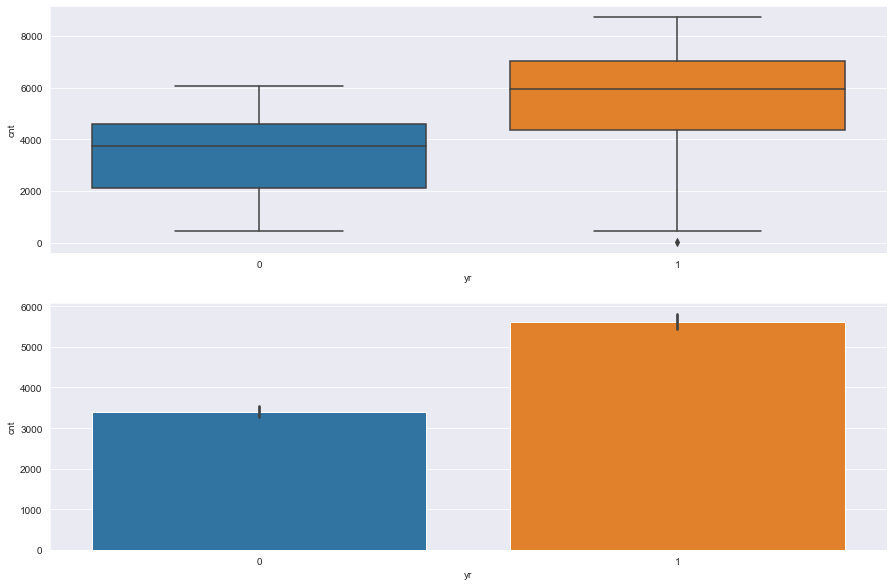

```python
#Plotting year vs Cnt
Categorical_plot('yr')
```

**Inferences**

- count of total rental bikes is considerably higher in `2019` as compared to `2018`

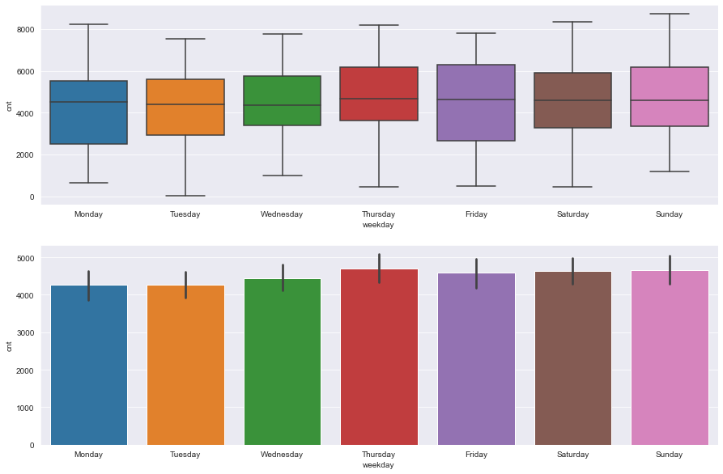

```python
#Plotting weekday vs Cnt
Categorical_plot('weekday')
```

**Inferences**

- count of total rental bikes is slighty higher on `Thrusday` as compared to other days.

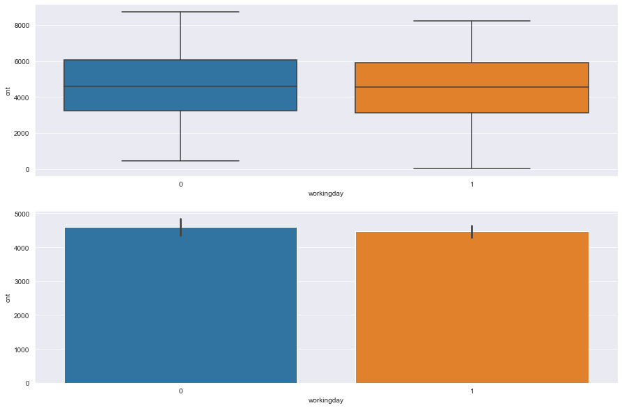

```python
#Plotting workingday vs Cnt
Categorical_plot('workingday')
```

**Inferences**

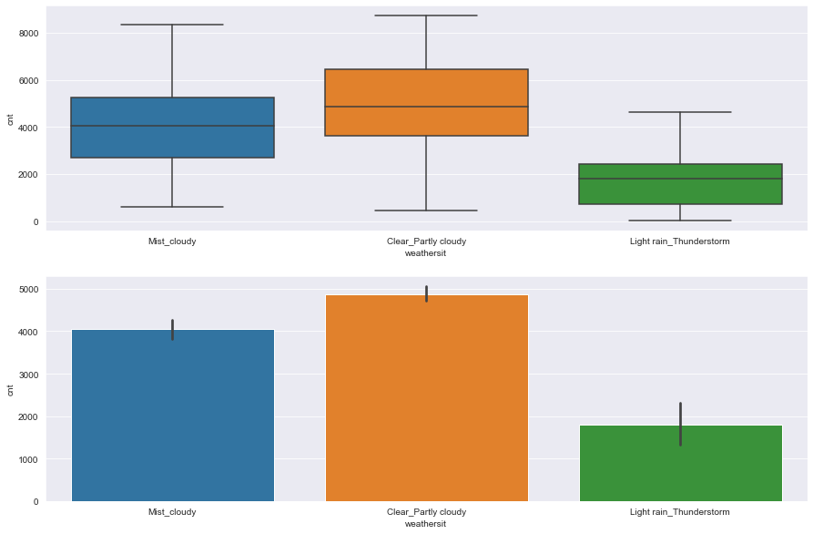

```python
#Plotting weathersit vs Cnt
Categorical_plot('weathersit')
```

**Inferences**

- count of total rental bikes is considerabley higher on `Clear` weather days.
- Count of total rental bikes is very low during `Rainy` days.

#### NUMERICAL VARIABLES

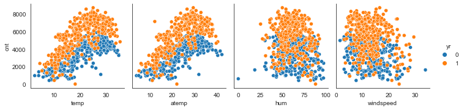

```python
# Plotting Pairplot to find linear relationship between the cnt variable and other numeric variables

sns.set_style("white")
x =sns.pairplot(bikes_df, palette='tab10', x_vars=['temp', 'atemp', 'hum', 'windspeed'], y_vars=['cnt'] , hue='yr')
plt.show()
```

**Inferences**

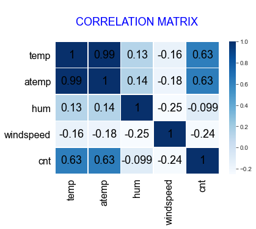

```python
# Plotting heatmap to define relationship between continuous variables

col = ['temp', 'atemp', 'hum', 'windspeed','cnt']
cor = bikes_df[col].corr()
plot_default= sns.heatmap(cor,annot_kws={'fontsize': 18,'fontweight': 6,'color': 'Black'},cmap="Blues",annot=True,linewidth=0.5)

plt.rcParams['figure.figsize']=(11, 7)
plot_default.axes.set_title('\n CORRELATION MATRIX \n',fontsize= 18,fontweight= 9,color='Blue')
plot_default.set_xticklabels(plot_default.get_xticklabels(), rotation = 90, fontsize = 16, color="Black")
plot_default.set_yticklabels(plot_default.get_yticklabels(), rotation = 0, fontsize = 16, color="Black")
plt.show()
```

**Inferences**

- `temp` and `atemp` variables are highly co-related with each-other

```python
# Column temp and atemp are highly co-related as the corelation is 0.99 which is almost 1
#Hence dropping temp variable

bikes_df.drop(['temp'],axis=1,inplace=True)
bikes_df.head()
```

|  | season | yr | mnth | holiday | weekday | workingday | weathersit | atemp | hum | windspeed | cnt |
| --- | --- | --- | --- | --- | --- | --- | --- | --- | --- | --- | --- |
| 0 | spring | 0 | Jan | 0 | Monday | 1 | Mist_cloudy | 18.18125 | 80.5833 | 10.749882 | 985 |
| 1 | spring | 0 | Jan | 0 | Tuesday | 1 | Mist_cloudy | 17.68695 | 69.6087 | 16.652113 | 801 |
| 2 | spring | 0 | Jan | 0 | Wednesday | 1 | Clear_Partly cloudy | 9.47025 | 43.7273 | 16.636703 | 1349 |
| 3 | spring | 0 | Jan | 0 | Thursday | 1 | Clear_Partly cloudy | 10.60610 | 59.0435 | 10.739832 | 1562 |
| 4 | spring | 0 | Jan | 0 | Friday | 1 | Clear_Partly cloudy | 11.46350 | 43.6957 | 12.522300 | 1600 |

### CREATING DUMMY VARIABLES

#### We need to create dummy variables for the following columns.

- season
- mnth
- weekday
- weathersit

```python
#All Categorical Variable in the dataset
bikes_categorical = bikes_df[['season', 'mnth', 'weekday', 'weathersit']]
print(bikes_categorical.columns)
```

```
Index(['season', 'mnth', 'weekday', 'weathersit'], dtype='object')
```

```python
#Creating Dummy variable and saving it under Dummy_var
dummy_var = pd.get_dummies(bikes_categorical, drop_first=True)
dummy_var.head()
```

|  | season_spring | season_summer | season_winter | mnth_Aug | mnth_Dec | mnth_Feb | mnth_Jan | mnth_Jul | mnth_Jun | mnth_Mar | mnth_May | mnth_Nov | mnth_Oct | mnth_Sep | weekday_Monday | weekday_Saturday | weekday_Sunday | weekday_Thursday | weekday_Tuesday | weekday_Wednesday | weathersit_Light rain_Thunderstorm | weathersit_Mist_cloudy |
| --- | --- | --- | --- | --- | --- | --- | --- | --- | --- | --- | --- | --- | --- | --- | --- | --- | --- | --- | --- | --- | --- | --- |
| 0 | 1 | 0 | 0 | 0 | 0 | 0 | 1 | 0 | 0 | 0 | 0 | 0 | 0 | 0 | 1 | 0 | 0 | 0 | 0 | 0 | 0 | 1 |
| 1 | 1 | 0 | 0 | 0 | 0 | 0 | 1 | 0 | 0 | 0 | 0 | 0 | 0 | 0 | 0 | 0 | 0 | 0 | 1 | 0 | 0 | 1 |
| 2 | 1 | 0 | 0 | 0 | 0 | 0 | 1 | 0 | 0 | 0 | 0 | 0 | 0 | 0 | 0 | 0 | 0 | 0 | 0 | 1 | 0 | 0 |
| 3 | 1 | 0 | 0 | 0 | 0 | 0 | 1 | 0 | 0 | 0 | 0 | 0 | 0 | 0 | 0 | 0 | 0 | 1 | 0 | 0 | 0 | 0 |
| 4 | 1 | 0 | 0 | 0 | 0 | 0 | 1 | 0 | 0 | 0 | 0 | 0 | 0 | 0 | 0 | 0 | 0 | 0 | 0 | 0 | 0 | 0 |

```python
#Concat operation for merging  dummy_var with bikes_df
bikes_df = pd.concat([bikes_df,dummy_var],axis=1)
bikes_df.head()
```

|  | season | yr | mnth | holiday | weekday | workingday | weathersit | atemp | hum | windspeed | cnt | season_spring | season_summer | season_winter | mnth_Aug | mnth_Dec | mnth_Feb | mnth_Jan | mnth_Jul | mnth_Jun | mnth_Mar | mnth_May | mnth_Nov | mnth_Oct | mnth_Sep | weekday_Monday | weekday_Saturday | weekday_Sunday | weekday_Thursday | … |
| --- | --- | --- | --- | --- | --- | --- | --- | --- | --- | --- | --- | --- | --- | --- | --- | --- | --- | --- | --- | --- | --- | --- | --- | --- | --- | --- | --- | --- | --- | --- |
| 0 | spring | 0 | Jan | 0 | Monday | 1 | Mist_cloudy | 18.18125 | 80.5833 | 10.749882 | 985 | 1 | 0 | 0 | 0 | 0 | 0 | 1 | 0 | 0 | 0 | 0 | 0 | 0 | 0 | 1 | 0 | 0 | 0 | … |
| 1 | spring | 0 | Jan | 0 | Tuesday | 1 | Mist_cloudy | 17.68695 | 69.6087 | 16.652113 | 801 | 1 | 0 | 0 | 0 | 0 | 0 | 1 | 0 | 0 | 0 | 0 | 0 | 0 | 0 | 0 | 0 | 0 | 0 | … |
| 2 | spring | 0 | Jan | 0 | Wednesday | 1 | Clear_Partly cloudy | 9.47025 | 43.7273 | 16.636703 | 1349 | 1 | 0 | 0 | 0 | 0 | 0 | 1 | 0 | 0 | 0 | 0 | 0 | 0 | 0 | 0 | 0 | 0 | 0 | … |
| 3 | spring | 0 | Jan | 0 | Thursday | 1 | Clear_Partly cloudy | 10.60610 | 59.0435 | 10.739832 | 1562 | 1 | 0 | 0 | 0 | 0 | 0 | 1 | 0 | 0 | 0 | 0 | 0 | 0 | 0 | 0 | 0 | 0 | 1 | … |
| 4 | spring | 0 | Jan | 0 | Friday | 1 | Clear_Partly cloudy | 11.46350 | 43.6957 | 12.522300 | 1600 | 1 | 0 | 0 | 0 | 0 | 0 | 1 | 0 | 0 | 0 | 0 | 0 | 0 | 0 | 0 | 0 | 0 | 0 | … |

```python
#Dropping Categorical Variable as dummy variables columns are now added to bikes_df
bikes_df.drop(list(bikes_categorical.columns), axis=1,inplace=True)
```

```python
#Checking the shape of dataframe after adding dummy variables
bikes_df.shape
```

```
(730, 29)
```

### Splitting the Data into Training and Testing Sets

```python
# We specify this so that the train and test data set always have the same rows, respectively
train_bikes,test_bikes = train_test_split(bikes_df, train_size = 0.7, test_size = 0.3, random_state = 100)
```

```python
# Verfying train_bikes dataframe(Train)
train_bikes.head()
```

|  | yr | holiday | workingday | atemp | hum | windspeed | cnt | season_spring | season_summer | season_winter | mnth_Aug | mnth_Dec | mnth_Feb | mnth_Jan | mnth_Jul | mnth_Jun | mnth_Mar | mnth_May | mnth_Nov | mnth_Oct | mnth_Sep | weekday_Monday | weekday_Saturday | weekday_Sunday | weekday_Thursday | weekday_Tuesday | weekday_Wednesday | weathersit_Light rain_Thunderstorm | weathersit_Mist_cloudy |
| --- | --- | --- | --- | --- | --- | --- | --- | --- | --- | --- | --- | --- | --- | --- | --- | --- | --- | --- | --- | --- | --- | --- | --- | --- | --- | --- | --- | --- | --- |
| 653 | 1 | 0 | 1 | 23.0423 | 55.8333 | 12.208807 | 7534 | 0 | 0 | 1 | 0 | 0 | 0 | 0 | 0 | 0 | 0 | 0 | 0 | 1 | 0 | 0 | 0 | 0 | 0 | 0 | 1 | 0 | 0 |
| 576 | 1 | 0 | 1 | 33.1448 | 70.4167 | 11.083475 | 7216 | 0 | 0 | 0 | 0 | 0 | 0 | 0 | 1 | 0 | 0 | 0 | 0 | 0 | 0 | 0 | 0 | 0 | 0 | 0 | 1 | 0 | 0 |
| 426 | 1 | 0 | 0 | 20.6746 | 62.1250 | 10.792293 | 4066 | 1 | 0 | 0 | 0 | 0 | 0 | 0 | 0 | 0 | 1 | 0 | 0 | 0 | 0 | 0 | 0 | 1 | 0 | 0 | 0 | 0 | 1 |
| 728 | 1 | 0 | 1 | 11.5850 | 48.3333 | 23.500518 | 1796 | 1 | 0 | 0 | 0 | 1 | 0 | 0 | 0 | 0 | 0 | 0 | 0 | 0 | 0 | 1 | 0 | 0 | 0 | 0 | 0 | 0 | 0 |
| 482 | 1 | 0 | 0 | 18.8752 | 48.9583 | 8.708325 | 4220 | 0 | 1 | 0 | 0 | 0 | 0 | 0 | 0 | 0 | 0 | 0 | 0 | 0 | 0 | 0 | 0 | 1 | 0 | 0 | 0 | 0 | 1 |

```python
# checking Datypes for train_bikes dataframe(Train)
train_bikes.info()
```

```
<class 'pandas.core.frame.DataFrame'>
Int64Index: 510 entries, 653 to 79
Data columns (total 29 columns):
 #   Column                              Non-Null Count  Dtype
---  ------                              --------------  -----
 0   yr                                  510 non-null    int64
 1   holiday                             510 non-null    int64
 2   workingday                          510 non-null    int64
 3   atemp                               510 non-null    float64
 4   hum                                 510 non-null    float64
 5   windspeed                           510 non-null    float64
 6   cnt                                 510 non-null    int64
 7   season_spring                       510 non-null    uint8
 8   season_summer                       510 non-null    uint8
 9   season_winter                       510 non-null    uint8
```

[output cut: 21 more lines]

#### Rescaling the features

```python
#SCALING THE NUMERICAL DATA
scaler=MinMaxScaler()
```

```python
numeric_var = ['atemp','hum','windspeed','cnt']
train_bikes[numeric_var] = scaler.fit_transform(train_bikes[numeric_var])
train_bikes.head()
```

|  | yr | holiday | workingday | atemp | hum | windspeed | cnt | season_spring | season_summer | season_winter | mnth_Aug | mnth_Dec | mnth_Feb | mnth_Jan | mnth_Jul | mnth_Jun | mnth_Mar | mnth_May | mnth_Nov | mnth_Oct | mnth_Sep | weekday_Monday | weekday_Saturday | weekday_Sunday | weekday_Thursday | weekday_Tuesday | weekday_Wednesday | weathersit_Light rain_Thunderstorm | weathersit_Mist_cloudy |
| --- | --- | --- | --- | --- | --- | --- | --- | --- | --- | --- | --- | --- | --- | --- | --- | --- | --- | --- | --- | --- | --- | --- | --- | --- | --- | --- | --- | --- | --- |
| 653 | 1 | 0 | 1 | 0.501133 | 0.575354 | 0.300794 | 0.864243 | 0 | 0 | 1 | 0 | 0 | 0 | 0 | 0 | 0 | 0 | 0 | 0 | 1 | 0 | 0 | 0 | 0 | 0 | 0 | 1 | 0 | 0 |
| 576 | 1 | 0 | 1 | 0.766351 | 0.725633 | 0.264686 | 0.827658 | 0 | 0 | 0 | 0 | 0 | 0 | 0 | 1 | 0 | 0 | 0 | 0 | 0 | 0 | 0 | 0 | 0 | 0 | 0 | 1 | 0 | 0 |
| 426 | 1 | 0 | 0 | 0.438975 | 0.640189 | 0.255342 | 0.465255 | 1 | 0 | 0 | 0 | 0 | 0 | 0 | 0 | 0 | 1 | 0 | 0 | 0 | 0 | 0 | 0 | 1 | 0 | 0 | 0 | 0 | 1 |
| 728 | 1 | 0 | 1 | 0.200348 | 0.498067 | 0.663106 | 0.204096 | 1 | 0 | 0 | 0 | 1 | 0 | 0 | 0 | 0 | 0 | 0 | 0 | 0 | 0 | 1 | 0 | 0 | 0 | 0 | 0 | 0 | 0 |
| 482 | 1 | 0 | 0 | 0.391735 | 0.504508 | 0.188475 | 0.482973 | 0 | 1 | 0 | 0 | 0 | 0 | 0 | 0 | 0 | 0 | 0 | 0 | 0 | 0 | 0 | 0 | 1 | 0 | 0 | 0 | 0 | 1 |

```python
# Verfying train_bikes dataframe(Train) after scaling
train_bikes.describe()
```

|  | yr | holiday | workingday | atemp | hum | windspeed | cnt | season_spring | season_summer | season_winter | mnth_Aug | mnth_Dec | mnth_Feb | mnth_Jan | mnth_Jul | mnth_Jun | mnth_Mar | mnth_May | mnth_Nov | mnth_Oct | mnth_Sep | weekday_Monday | weekday_Saturday | weekday_Sunday | weekday_Thursday | weekday_Tuesday | weekday_Wednesday | weathersit_Light rain_Thunderstorm | weathersit_Mist_cloudy |
| --- | --- | --- | --- | --- | --- | --- | --- | --- | --- | --- | --- | --- | --- | --- | --- | --- | --- | --- | --- | --- | --- | --- | --- | --- | --- | --- | --- | --- | --- |
| count | 510.000000 | 510.000000 | 510.000000 | 510.000000 | 510.000000 | 510.000000 | 510.000000 | 510.000000 | 510.000000 | 510.00000 | 510.000000 | 510.000000 | 510.000000 | 510.000000 | 510.000000 | 510.000000 | 510.000000 | 510.000000 | 510.000000 | 510.000000 | 510.000000 | 510.000000 | 510.000000 | 510.000000 | 510.000000 | 510.000000 | 510.000000 | 510.000000 | 510.000000 |
| mean | 0.507843 | 0.025490 | 0.711765 | 0.512989 | 0.650369 | 0.320768 | 0.513620 | 0.243137 | 0.245098 | 0.24902 | 0.096078 | 0.084314 | 0.066667 | 0.088235 | 0.076471 | 0.074510 | 0.098039 | 0.084314 | 0.086275 | 0.086275 | 0.080392 | 0.154902 | 0.129412 | 0.137255 | 0.143137 | 0.152941 | 0.135294 | 0.029412 | 0.343137 |
| std | 0.500429 | 0.157763 | 0.453386 | 0.212385 | 0.145882 | 0.169797 | 0.224593 | 0.429398 | 0.430568 | 0.43287 | 0.294988 | 0.278131 | 0.249689 | 0.283915 | 0.266010 | 0.262857 | 0.297660 | 0.278131 | 0.281045 | 0.281045 | 0.272166 | 0.362166 | 0.335985 | 0.344454 | 0.350557 | 0.360284 | 0.342373 | 0.169124 | 0.475223 |
| min | 0.000000 | 0.000000 | 0.000000 | 0.000000 | 0.000000 | 0.000000 | 0.000000 | 0.000000 | 0.000000 | 0.00000 | 0.000000 | 0.000000 | 0.000000 | 0.000000 | 0.000000 | 0.000000 | 0.000000 | 0.000000 | 0.000000 | 0.000000 | 0.000000 | 0.000000 | 0.000000 | 0.000000 | 0.000000 | 0.000000 | 0.000000 | 0.000000 | 0.000000 |
| 25% | 0.000000 | 0.000000 | 0.000000 | 0.332086 | 0.538643 | 0.199179 | 0.356420 | 0.000000 | 0.000000 | 0.00000 | 0.000000 | 0.000000 | 0.000000 | 0.000000 | 0.000000 | 0.000000 | 0.000000 | 0.000000 | 0.000000 | 0.000000 | 0.000000 | 0.000000 | 0.000000 | 0.000000 | 0.000000 | 0.000000 | 0.000000 | 0.000000 | 0.000000 |
| 50% | 1.000000 | 0.000000 | 1.000000 | 0.526811 | 0.653714 | 0.296763 | 0.518638 | 0.000000 | 0.000000 | 0.00000 | 0.000000 | 0.000000 | 0.000000 | 0.000000 | 0.000000 | 0.000000 | 0.000000 | 0.000000 | 0.000000 | 0.000000 | 0.000000 | 0.000000 | 0.000000 | 0.000000 | 0.000000 | 0.000000 | 0.000000 | 0.000000 | 0.000000 |
| 75% | 1.000000 | 0.000000 | 1.000000 | 0.688457 | 0.754830 | 0.414447 | 0.684710 | 0.000000 | 0.000000 | 0.00000 | 0.000000 | 0.000000 | 0.000000 | 0.000000 | 0.000000 | 0.000000 | 0.000000 | 0.000000 | 0.000000 | 0.000000 | 0.000000 | 0.000000 | 0.000000 | 0.000000 | 0.000000 | 0.000000 | 0.000000 | 0.000000 | 1.000000 |
| max | 1.000000 | 1.000000 | 1.000000 | 1.000000 | 1.000000 | 1.000000 | 1.000000 | 1.000000 | 1.000000 | 1.00000 | 1.000000 | 1.000000 | 1.000000 | 1.000000 | 1.000000 | 1.000000 | 1.000000 | 1.000000 | 1.000000 | 1.000000 | 1.000000 | 1.000000 | 1.000000 | 1.000000 | 1.000000 | 1.000000 | 1.000000 | 1.000000 | 1.000000 |

```python
# checking Datypes for train_bikes dataframe(Train) after scaling
train_bikes.info()
```

```
<class 'pandas.core.frame.DataFrame'>
Int64Index: 510 entries, 653 to 79
Data columns (total 29 columns):
 #   Column                              Non-Null Count  Dtype
---  ------                              --------------  -----
 0   yr                                  510 non-null    int64
 1   holiday                             510 non-null    int64
 2   workingday                          510 non-null    int64
 3   atemp                               510 non-null    float64
 4   hum                                 510 non-null    float64
 5   windspeed                           510 non-null    float64
 6   cnt                                 510 non-null    float64
 7   season_spring                       510 non-null    uint8
 8   season_summer                       510 non-null    uint8
 9   season_winter                       510 non-null    uint8
```

[output cut: 21 more lines]

#### Dividing into x and y sets for model building

```python
#CREATING X AND Y
y_train = train_bikes.pop('cnt')
X_train = train_bikes
```

```python
# Verifying X_train
X_train.head()
```

|  | yr | holiday | workingday | atemp | hum | windspeed | season_spring | season_summer | season_winter | mnth_Aug | mnth_Dec | mnth_Feb | mnth_Jan | mnth_Jul | mnth_Jun | mnth_Mar | mnth_May | mnth_Nov | mnth_Oct | mnth_Sep | weekday_Monday | weekday_Saturday | weekday_Sunday | weekday_Thursday | weekday_Tuesday | weekday_Wednesday | weathersit_Light rain_Thunderstorm | weathersit_Mist_cloudy |
| --- | --- | --- | --- | --- | --- | --- | --- | --- | --- | --- | --- | --- | --- | --- | --- | --- | --- | --- | --- | --- | --- | --- | --- | --- | --- | --- | --- | --- |
| 653 | 1 | 0 | 1 | 0.501133 | 0.575354 | 0.300794 | 0 | 0 | 1 | 0 | 0 | 0 | 0 | 0 | 0 | 0 | 0 | 0 | 1 | 0 | 0 | 0 | 0 | 0 | 0 | 1 | 0 | 0 |
| 576 | 1 | 0 | 1 | 0.766351 | 0.725633 | 0.264686 | 0 | 0 | 0 | 0 | 0 | 0 | 0 | 1 | 0 | 0 | 0 | 0 | 0 | 0 | 0 | 0 | 0 | 0 | 0 | 1 | 0 | 0 |
| 426 | 1 | 0 | 0 | 0.438975 | 0.640189 | 0.255342 | 1 | 0 | 0 | 0 | 0 | 0 | 0 | 0 | 0 | 1 | 0 | 0 | 0 | 0 | 0 | 0 | 1 | 0 | 0 | 0 | 0 | 1 |
| 728 | 1 | 0 | 1 | 0.200348 | 0.498067 | 0.663106 | 1 | 0 | 0 | 0 | 1 | 0 | 0 | 0 | 0 | 0 | 0 | 0 | 0 | 0 | 1 | 0 | 0 | 0 | 0 | 0 | 0 | 0 |
| 482 | 1 | 0 | 0 | 0.391735 | 0.504508 | 0.188475 | 0 | 1 | 0 | 0 | 0 | 0 | 0 | 0 | 0 | 0 | 0 | 0 | 0 | 0 | 0 | 0 | 1 | 0 | 0 | 0 | 0 | 1 |

```python
# Verifying Y_train
y_train.head()
```

```
653    0.864243
576    0.827658
426    0.465255
728    0.204096
482    0.482973
Name: cnt, dtype: float64
```

### Building model

#### RFE

```python
#USING RFE APPROACH FOR FEATURE SELECTION
# WE START WITH 15 VARS

lm = LinearRegression()
lm.fit(X_train, y_train)

rfe = RFE(lm, 15)
rfe = rfe.fit(X_train, y_train)
```

```python
list(zip(X_train.columns,rfe.support_,rfe.ranking_))
```

```
[('yr', True, 1),
 ('holiday', True, 1),
 ('workingday', False, 2),
 ('atemp', True, 1),
 ('hum', True, 1),
 ('windspeed', True, 1),
 ('season_spring', False, 5),
 ('season_summer', True, 1),
 ('season_winter', True, 1),
 ('mnth_Aug', True, 1),
 ('mnth_Dec', True, 1),
 ('mnth_Feb', True, 1),
 ('mnth_Jan', True, 1),
 ('mnth_Jul', False, 10),
 ('mnth_Jun', False, 7),
 ('mnth_Mar', False, 14),
 ('mnth_May', False, 6),
 ('mnth_Nov', True, 1),
 ('mnth_Oct', False, 12),
 ('mnth_Sep', True, 1),
 ('weekday_Monday', False, 9),
 ('weekday_Saturday', False, 3),
 ('weekday_Sunday', False, 4),
 ('weekday_Thursday', False, 13),
 ('weekday_Tuesday', False, 8),
 ('weekday_Wednesday', False, 11),
 ('weathersit_Light rain_Thunderstorm', True, 1),
 ('weathersit_Mist_cloudy', True, 1)]
```

#### Model Building

```python
#Creating build_model function which will return lm and X_train_rfe values

def build_model(X_train_rfe):

    X_train_rfe1 = sm.add_constant(X_train_rfe) # Adding a constant variable
    lm = sm.OLS(y_train,X_train_rfe1).fit()
    X_train_sm = sm.add_constant(X_train_rfe)
    lm = sm.OLS(y_train, X_train_sm).fit()
    return lm,X_train_rfe1
```

```python
#Creating check_vif function which will return vif values

def check_vif(X_train_rfe):
    vif = pd.DataFrame()
    X = X_train_rfe
    vif['Features'] = X.columns
    vif['VIF'] = [variance_inflation_factor(X.values, i) for i in range(X.shape[1])]
    vif['VIF'] = round(vif['VIF'], 2)
    vif = vif.sort_values(by = "VIF", ascending = False)
    return vif
```

#### Building Model-1

```python
X_train.columns[rfe.support_]
```

```
Index(['yr', 'holiday', 'atemp', 'hum', 'windspeed', 'season_summer',
       'season_winter', 'mnth_Aug', 'mnth_Dec', 'mnth_Feb', 'mnth_Jan',
       'mnth_Nov', 'mnth_Sep', 'weathersit_Light rain_Thunderstorm',
       'weathersit_Mist_cloudy'],
      dtype='object')
```

```python
X_train.columns[~rfe.support_]
```

```
Index(['workingday', 'season_spring', 'mnth_Jul', 'mnth_Jun', 'mnth_Mar',
       'mnth_May', 'mnth_Oct', 'weekday_Monday', 'weekday_Saturday',
       'weekday_Sunday', 'weekday_Thursday', 'weekday_Tuesday',
       'weekday_Wednesday'],
      dtype='object')
```

```python
#Passing values to build_model fucntion to build model

col = X_train.columns[rfe.support_]
X_train_rfe = X_train[col]
lm1,X_train_rfe1 =build_model(X_train_rfe)
lm1_vif = check_vif(X_train_rfe)
```

```python
# Printing summary of the model
print(lm1.summary())
```

```
                            OLS Regression Results
==============================================================================
Dep. Variable:                    cnt   R-squared:                       0.842
Model:                            OLS   Adj. R-squared:                  0.837
Method:                 Least Squares   F-statistic:                     175.1
Date:                Wed, 05 Jan 2022   Prob (F-statistic):          1.26e-186
Time:                        18:04:29   Log-Likelihood:                 508.57
No. Observations:                 510   AIC:                            -985.1
Df Residuals:                     494   BIC:                            -917.4
Df Model:                          15
Covariance Type:            nonrobust
======================================================================================================
                                         coef    std err          t      P>|t|      [0.025      0.975]
------------------------------------------------------------------------------------------------------
const                                  0.2936      0.032      9.289      0.000       0.232       0.356
yr                                     0.2311      0.008     28.328      0.000       0.215       0.247
holiday                               -0.0838      0.026     -3.233      0.001      -0.135      -0.033
atemp                                  0.4765      0.032     14.938      0.000       0.414       0.539
hum                                   -0.1627      0.038     -4.277      0.000      -0.237      -0.088
windspeed                             -0.1769      0.026     -6.784      0.000      -0.228      -0.126
season_summer                          0.0779      0.013      6.180      0.000       0.053       0.103
season_winter                          0.1358      0.014      9.541      0.000       0.108       0.164
mnth_Aug                               0.0606      0.016      3.696      0.000       0.028       0.093
mnth_Dec                              -0.0505      0.018     -2.732      0.007      -0.087      -0.014
mnth_Feb                              -0.0504      0.021     -2.384      0.017      -0.092      -0.009
mnth_Jan                              -0.0769      0.021     -3.617      0.000      -0.119      -0.035
mnth_Nov                              -0.0440      0.019     -2.316      0.021      -0.081      -0.007
mnth_Sep                               0.1116      0.017      6.688      0.000       0.079       0.144
weathersit_Light rain_Thunderstorm    -0.2420      0.027     -9.070      0.000      -0.294      -0.190
weathersit_Mist_cloudy                -0.0569      0.011     -5.377      0.000      -0.078      -0.036
==============================================================================
Omnibus:                       67.622   Durbin-Watson:                   2.017
Prob(Omnibus):                  0.000   Jarque-Bera (JB):              171.611
Skew:                          -0.675   Prob(JB):                     5.43e-38
Kurtosis:                       5.501   Cond. No.                         18.7
==============================================================================

Notes:
[1] Standard Errors assume that the covariance matrix of the errors is correctly specified.
```

```python
#Printing VIF summary for the model
print(lm1_vif)
```

```
                              Features    VIF
3                                  hum  25.11
2                                atemp  14.42
4                            windspeed   3.89
6                        season_winter   3.04
5                        season_summer   2.28
14              weathersit_Mist_cloudy   2.24
0                                   yr   2.06
10                            mnth_Jan   1.92
11                            mnth_Nov   1.85
8                             mnth_Dec   1.63
7                             mnth_Aug   1.60
9                             mnth_Feb   1.55
12                            mnth_Sep   1.38
13  weathersit_Light rain_Thunderstorm   1.25
1                              holiday   1.06
```

**Inferences**

- `P-values` are less than `0.05` for all the observed features for Model-1.
- Higher `VIF` value is very high for `hum` column for Model-1.

**NOTE:**

- **VIF less than 5 is considered to be in acceptable range**
- **P-Value less than 0.05 is considered to be in acceptable range**

#### Building Model-2

```python
#COLUMN hum HAS A VERY HIGH VIF SO WE DROP IT
X_train_rfe=X_train_rfe.drop(['hum'],axis=1)
```

```python
#Passing values to build_model fucntion to build model 2
lm2,X_train_rfe2 =build_model(X_train_rfe)
lm2_vif = check_vif(X_train_rfe)
```

```python
# Printing summary of the model
print(lm2.summary())
```

```
                            OLS Regression Results
==============================================================================
Dep. Variable:                    cnt   R-squared:                       0.836
Model:                            OLS   Adj. R-squared:                  0.831
Method:                 Least Squares   F-statistic:                     180.0
Date:                Wed, 05 Jan 2022   Prob (F-statistic):          7.00e-184
Time:                        18:04:29   Log-Likelihood:                 499.30
No. Observations:                 510   AIC:                            -968.6
Df Residuals:                     495   BIC:                            -905.1
Df Model:                          14
Covariance Type:            nonrobust
======================================================================================================
                                         coef    std err          t      P>|t|      [0.025      0.975]
------------------------------------------------------------------------------------------------------
const                                  0.2114      0.026      8.281      0.000       0.161       0.262
yr                                     0.2349      0.008     28.475      0.000       0.219       0.251
holiday                               -0.0851      0.026     -3.229      0.001      -0.137      -0.033
atemp                                  0.4432      0.031     14.084      0.000       0.381       0.505
windspeed                             -0.1493      0.026     -5.808      0.000      -0.200      -0.099
season_summer                          0.0723      0.013      5.671      0.000       0.047       0.097
season_winter                          0.1244      0.014      8.746      0.000       0.096       0.152
mnth_Aug                               0.0580      0.017      3.479      0.001       0.025       0.091
mnth_Dec                              -0.0585      0.019     -3.132      0.002      -0.095      -0.022
mnth_Feb                              -0.0565      0.021     -2.636      0.009      -0.099      -0.014
mnth_Jan                              -0.0875      0.021     -4.070      0.000      -0.130      -0.045
mnth_Nov                              -0.0442      0.019     -2.287      0.023      -0.082      -0.006
mnth_Sep                               0.1044      0.017      6.180      0.000       0.071       0.138
weathersit_Light rain_Thunderstorm    -0.2875      0.025    -11.540      0.000      -0.336      -0.239
weathersit_Mist_cloudy                -0.0828      0.009     -9.371      0.000      -0.100      -0.065
==============================================================================
Omnibus:                       67.944   Durbin-Watson:                   2.028
Prob(Omnibus):                  0.000   Jarque-Bera (JB):              170.080
Skew:                          -0.682   Prob(JB):                     1.17e-37
Kurtosis:                       5.478   Cond. No.                         16.1
==============================================================================

Notes:
[1] Standard Errors assume that the covariance matrix of the errors is correctly specified.
```

```python
#Printing VIF summary for the model
print(lm2_vif)
```

```
                              Features   VIF
2                                atemp  4.99
3                            windspeed  3.83
5                        season_winter  2.62
0                                   yr  2.06
4                        season_summer  2.04
10                            mnth_Nov  1.81
6                             mnth_Aug  1.59
13              weathersit_Mist_cloudy  1.57
7                             mnth_Dec  1.41
11                            mnth_Sep  1.35
9                             mnth_Jan  1.29
8                             mnth_Feb  1.26
12  weathersit_Light rain_Thunderstorm  1.09
1                              holiday  1.06
```

**Inferences**

- `P-values` are less than `0.05` for all the observed features for Model-2.
- `VIF` value is also less than `5` for all the observed for Model-2.

**NOTE:**

- **VIF less than 5 is considered to be in acceptable range**
- **P-Value less than 0.05 is considered to be in acceptable range**

### Residual Analysis of the train data

- As per assumptions of liner regression, Error terms should be normally distributed.
- So, we will be plotting Error terms to verify the same.

```python
#Predict values
y_train_cnt = lm2.predict(X_train_rfe2)
```

```python
#CALCULATING RESIDUALS
res=y_train - y_train_cnt
```

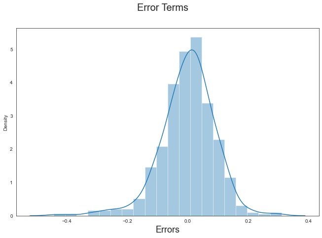

```python
# Plot the histogram/distplot of the error terms
fig = plt.figure()
sns.distplot((res), bins = 20)
fig.suptitle('Error Terms', fontsize = 20)                  # Plot heading
plt.xlabel('Errors', fontsize = 18)                         # X-label
```

**Inferences**

- `Error Terms` are normally distributed for Model-2.

### Making Predictions

#### Applying the scaling on the test sets

```python
#Scaling the test data

numeric_var = ['atemp','hum','windspeed','cnt']
test_bikes[numeric_var] = scaler.fit_transform(test_bikes[numeric_var])
test_bikes.head()
```

|  | yr | holiday | workingday | atemp | hum | windspeed | cnt | season_spring | season_summer | season_winter | mnth_Aug | mnth_Dec | mnth_Feb | mnth_Jan | mnth_Jul | mnth_Jun | mnth_Mar | mnth_May | mnth_Nov | mnth_Oct | mnth_Sep | weekday_Monday | weekday_Saturday | weekday_Sunday | weekday_Thursday | weekday_Tuesday | weekday_Wednesday | weathersit_Light rain_Thunderstorm | weathersit_Mist_cloudy |
| --- | --- | --- | --- | --- | --- | --- | --- | --- | --- | --- | --- | --- | --- | --- | --- | --- | --- | --- | --- | --- | --- | --- | --- | --- | --- | --- | --- | --- | --- |
| 184 | 0 | 1 | 0 | 0.778767 | 0.534223 | 0.149393 | 0.704300 | 0 | 0 | 0 | 0 | 0 | 0 | 0 | 1 | 0 | 0 | 0 | 0 | 0 | 0 | 0 | 0 | 0 | 0 | 0 | 1 | 0 | 1 |
| 535 | 1 | 0 | 1 | 0.855132 | 0.470417 | 0.231142 | 0.725421 | 0 | 1 | 0 | 0 | 0 | 0 | 0 | 0 | 1 | 0 | 0 | 0 | 0 | 0 | 0 | 0 | 0 | 1 | 0 | 0 | 0 | 0 |
| 299 | 0 | 0 | 0 | 0.492359 | 0.777843 | 0.443398 | 0.278853 | 0 | 0 | 1 | 0 | 0 | 0 | 0 | 0 | 0 | 0 | 0 | 0 | 1 | 0 | 0 | 1 | 0 | 0 | 0 | 0 | 0 | 1 |
| 221 | 0 | 0 | 1 | 0.805661 | 0.236659 | 0.449707 | 0.545512 | 0 | 0 | 0 | 1 | 0 | 0 | 0 | 0 | 0 | 0 | 0 | 0 | 0 | 0 | 0 | 0 | 0 | 0 | 0 | 0 | 0 | 0 |
| 152 | 0 | 0 | 0 | 0.749249 | 0.070765 | 0.682387 | 0.569148 | 0 | 1 | 0 | 0 | 0 | 0 | 0 | 0 | 1 | 0 | 0 | 0 | 0 | 0 | 0 | 1 | 0 | 0 | 0 | 0 | 0 | 0 |

#### Dividing into X_test and y_test

```python
#Creating x and y sets
y_test = test_bikes.pop('cnt')
X_test = test_bikes
```

```python
X_train_new = X_train_rfe2.drop(['const'], axis=1)
```

```python
# Now let's use our model to make predictions.
# Creating X_test_new dataframe by dropping variables from X_test

X_test_new = X_test[X_train_new.columns]

# Adding a constant variable
X_test_new = sm.add_constant(X_test_new)
```

```python
#Making predictions on the chosen model
y_pred = lm2.predict(X_test_new)
```

### Model Evaluation

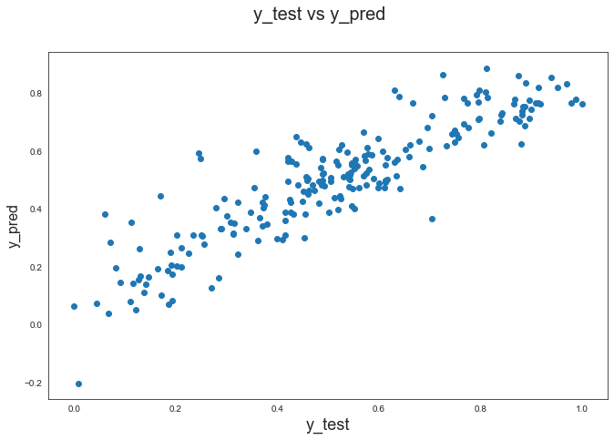

```python
#CHECKING PREDICTED V/s TEST DATA

fig = plt.figure()
plt.scatter(y_test,y_pred)
fig.suptitle('y_test vs y_pred', fontsize=20)              # Plot heading
plt.xlabel('y_test', fontsize=18)                          # X-label
plt.ylabel('y_pred', fontsize=16)
```

**Inferences**

- For Model-2, actual value(y_test) and predicted value(y_pred) resembles a `strong` relation pattern.
- This shows that model is good enough to predict the count of rental bikes

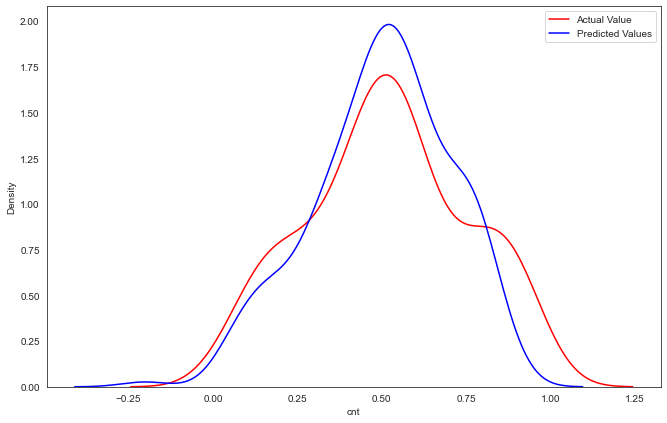

```python
# Plotting Actual Value Vs Predicted Values
ax1 = sns.distplot(y_test, hist=False, color="r", label="Actual Value")
sns.distplot(y_pred, hist=False, color="b", label="Predicted Values" , ax=ax1)
plt.legend()
plt.show()
```

**Inferences**

- For Model-2, actual value(y_test) and predicted value(y_pred) follows `similar` curve pattern.
- This shows that model is good enough to predict the count of rental bikes

```python
#Verifying the mean squared error and then calculating square root(Train)
np.sqrt(mean_squared_error(y_train, y_train_cnt))
```

```
0.09090426622956872
```

```python
#Verifying the mean squared error and then calculating square root(Test)
np.sqrt(mean_squared_error(y_test, y_pred))
```

```
0.10731887622842817
```

```python
#Calculate the r square for train
r_squared_train = r2_score(y_train, y_train_cnt)
round(r_squared_train,4)
```

```
0.8359
```

```python
#Calculate the r square for test

r_squared = r2_score(y_test, y_pred)
round(r_squared,4)
```

```
0.7969
```

**Inferences**

- R square of model is **`79.69%`**

```python
#Taking year column data
X_t=X_train_new.iloc[:,0].values
```

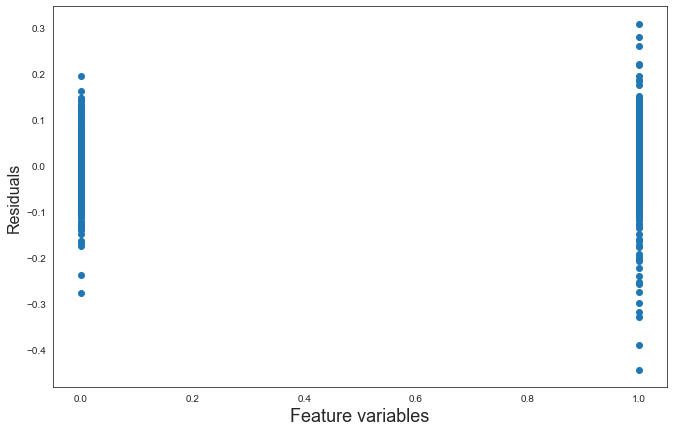

```python
#PLotting the residuals to see if a pattern exists between the two year data(0 = 2018, 1 = 2019)
#Checking assumption of homoscedasticity and autocorrelation
plt.figure()
plt.scatter(X_t,res)
fig.suptitle('Feature variables vs res', fontsize=20)              # Plot heading
plt.xlabel('Feature variables', fontsize=18)                          # X-label
plt.ylabel('Residuals', fontsize=16)
plt.show()
```

**Inferences**

### Equation for best fitted line

```python
# checking the dataframe
X_train_new.head()
```

|  | yr | holiday | atemp | windspeed | season_summer | season_winter | mnth_Aug | mnth_Dec | mnth_Feb | mnth_Jan | mnth_Nov | mnth_Sep | weathersit_Light rain_Thunderstorm | weathersit_Mist_cloudy |
| --- | --- | --- | --- | --- | --- | --- | --- | --- | --- | --- | --- | --- | --- | --- |
| 653 | 1 | 0 | 0.501133 | 0.300794 | 0 | 1 | 0 | 0 | 0 | 0 | 0 | 0 | 0 | 0 |
| 576 | 1 | 0 | 0.766351 | 0.264686 | 0 | 0 | 0 | 0 | 0 | 0 | 0 | 0 | 0 | 0 |
| 426 | 1 | 0 | 0.438975 | 0.255342 | 0 | 0 | 0 | 0 | 0 | 0 | 0 | 0 | 0 | 1 |
| 728 | 1 | 0 | 0.200348 | 0.663106 | 0 | 0 | 0 | 1 | 0 | 0 | 0 | 0 | 0 | 0 |
| 482 | 1 | 0 | 0.391735 | 0.188475 | 1 | 0 | 0 | 0 | 0 | 0 | 0 | 0 | 0 | 1 |

```python
#Printing columns and summary for model-2 to write equation

print(X_train_rfe2.columns)
print(lm2.summary())
```

```
Index(['const', 'yr', 'holiday', 'atemp', 'windspeed', 'season_summer',
       'season_winter', 'mnth_Aug', 'mnth_Dec', 'mnth_Feb', 'mnth_Jan',
       'mnth_Nov', 'mnth_Sep', 'weathersit_Light rain_Thunderstorm',
       'weathersit_Mist_cloudy'],
      dtype='object')
                            OLS Regression Results
==============================================================================
Dep. Variable:                    cnt   R-squared:                       0.836
Model:                            OLS   Adj. R-squared:                  0.831
Method:                 Least Squares   F-statistic:                     180.0
Date:                Wed, 05 Jan 2022   Prob (F-statistic):          7.00e-184
Time:                        18:04:33   Log-Likelihood:                 499.30
No. Observations:                 510   AIC:                            -968.6
Df Residuals:                     495   BIC:                            -905.1
Df Model:                          14
Covariance Type:            nonrobust
======================================================================================================
                                         coef    std err          t      P>|t|      [0.025      0.975]
------------------------------------------------------------------------------------------------------
const                                  0.2114      0.026      8.281      0.000       0.161       0.262
yr                                     0.2349      0.008     28.475      0.000       0.219       0.251
holiday                               -0.0851      0.026     -3.229      0.001      -0.137      -0.033
atemp                                  0.4432      0.031     14.084      0.000       0.381       0.505
windspeed                             -0.1493      0.026     -5.808      0.000      -0.200      -0.099
season_summer                          0.0723      0.013      5.671      0.000       0.047       0.097
season_winter                          0.1244      0.014      8.746      0.000       0.096       0.152
mnth_Aug                               0.0580      0.017      3.479      0.001       0.025       0.091
mnth_Dec                              -0.0585      0.019     -3.132      0.002      -0.095      -0.022
mnth_Feb                              -0.0565      0.021     -2.636      0.009      -0.099      -0.014
mnth_Jan                              -0.0875      0.021     -4.070      0.000      -0.130      -0.045
mnth_Nov                              -0.0442      0.019     -2.287      0.023      -0.082      -0.006
mnth_Sep                               0.1044      0.017      6.180      0.000       0.071       0.138
weathersit_Light rain_Thunderstorm    -0.2875      0.025    -11.540      0.000      -0.336      -0.239
weathersit_Mist_cloudy                -0.0828      0.009     -9.371      0.000      -0.100      -0.065
==============================================================================
Omnibus:                       67.944   Durbin-Watson:                   2.028
Prob(Omnibus):                  0.000   Jarque-Bera (JB):              170.080
Skew:                          -0.682   Prob(JB):                     1.17e-37
Kurtosis:                       5.478   Cond. No.                         16.1
==============================================================================

Notes:
[1] Standard Errors assume that the covariance matrix of the errors is correctly specified.
```

So, the equation of our best fitted line is

### Equation

**cnt** = (**0.2349** *yr) - (**0.0851*** holiday) + (**0.4432** *atemp) - (**0.1493*** windspeed) + (**0.0723** *season_summer) + (**0.1244*** season_winter) + (**0.0580** *mnth_Aug) - (**0.0585*** mnth_Dec) - (**0.0565** *mnth_Feb) - (**0.0875*** mnth_Jan) - (**0.0442** *mnth_Nov) + (**0.1044*** mnth_Sep) - (**0.2875** *weathersit_Light rain_Thunderstorm) - (**0.0828*** weathersit_Mist_cloudy) + **0.2114**

### Observation

#### count of total rental bikes is dependent mainly on below features:

- year
- holiday
- Temperature(atemp)
- windspeed
- Season: season_summer,season_winter
- Month: mnth_Aug, mnth_Dec,mnth_Feb,mnth_Jan,mnth_Nov,mnth_Sep
- weathersit: weathersit_Light rain_Thunderstorm, weathersit_Mist_cloudy

#### count of total rental bikes decreases with increase in below features(Inversely-proportional):

- holiday
- windspeed
- Month: mnth_Dec,mnth_Feb,mnth_Jan,mnth_Nov
- weathersit: weathersit_Light rain_Thunderstorm, weathersit_Mist_cloudy